# ExtraaLearn Project

## Context

The EdTech industry has been surging in the past decade immensely, and according to a forecast, the Online Education market would be worth $286.62bn by 2023 with a compound annual growth rate (CAGR) of 10.26% from 2018 to 2023. The modern era of online education has enforced a lot in its growth and expansion beyond any limit. Due to having many dominant features like ease of information sharing, personalized learning experience, transparency of assessment, etc, it is now preferable to traditional education.

In the present scenario due to the Covid-19, the online education sector has witnessed rapid growth and is attracting a lot of new customers. Due to this rapid growth, many new companies have emerged in this industry. With the availability and ease of use of digital marketing resources, companies can reach out to a wider audience with their offerings. The customers who show interest in these offerings are termed as leads. There are various sources of obtaining leads for Edtech companies, like

- The customer interacts with the marketing front on social media or other online platforms.
- The customer browses the website/app and downloads the brochure
- The customer connects through emails for more information.

The company then nurtures these leads and tries to convert them to paid customers. For this, the representative from the organization connects with the lead on call or through email to share further details.

## Objective

ExtraaLearn is an initial stage startup that offers programs on cutting-edge technologies to students and professionals to help them upskill/reskill. With a large number of leads being generated on a regular basis, one of the issues faced by ExtraaLearn is to identify which of the leads are more likely to convert so that they can allocate resources accordingly. You, as a data scientist at ExtraaLearn, have been provided the leads data to:

- Analyze and build an ML model to help identify which leads are more likely to convert to paid customers,
- Find the factors driving the lead conversion process
- Create a profile of the leads which are likely to convert

## Data Description

The data contains the different attributes of leads and their interaction details with ExtraaLearn. The detailed data dictionary is given below.

**Data Dictionary**

- ID: ID of the lead
- age: Age of the lead
- current_occupation: Current occupation of the lead. Values include 'Professional','Unemployed',and 'Student'
- first_interaction: How did the lead first interacted with ExtraaLearn. Values include 'Website', 'Mobile App'
- profile_completed: What percentage of profile has been filled by the lead on the website/mobile app. Values include Low - (0-50%), Medium - (50-75%), High (75-100%)
- website_visits: How many times has a lead visited the website
- time_spent_on_website: Total time spent on the website
- page_views_per_visit: Average number of pages on the website viewed during the visits.
- last_activity: Last interaction between the lead and ExtraaLearn.
  - Email Activity: Seeking for details about program through email, Representative shared information with lead like brochure of program , etc
  - Phone Activity: Had a Phone Conversation with representative, Had conversation over SMS with representative, etc
  - Website Activity: Interacted on live chat with representative, Updated profile on website, etc
- print_media_type1: Flag indicating whether the lead had seen the ad of ExtraaLearn in the Newspaper.
- print_media_type2: Flag indicating whether the lead had seen the ad of ExtraaLearn in the Magazine.
- digital_media: Flag indicating whether the lead had seen the ad of ExtraaLearn on the digital platforms.
- educational_channels: Flag indicating whether the lead had heard about ExtraaLearn in the education channels like online forums, discussion threads, educational websites, etc.
- referral: Flag indicating whether the lead had heard about ExtraaLearn through reference.
- status: Flag indicating whether the lead was converted to a paid customer or not.

## Importing necessary libraries and data

```python
import pandas as pd
import numpy as np
import matplotlib.pyplot as plt
import seaborn as sns

import warnings
warnings.filterwarnings("ignore")

# Removes the limit for the number of displayed columns
pd.set_option("display.max_columns", None)

# Sets the limit for the number of displayed rows
pd.set_option("display.max_rows", 200)

# To build models for prediction
from sklearn.model_selection import train_test_split, cross_val_score, KFold
from sklearn.tree import DecisionTreeClassifier
from sklearn.ensemble import RandomForestClassifier

# Metrics to evaluate the model
from sklearn import metrics
from sklearn.metrics import confusion_matrix, classification_report
from sklearn import tree

# To encode categorical variables
from sklearn.preprocessing import LabelEncoder

# For tuning the model
from sklearn.model_selection import GridSearchCV
```

```python
# mount drive
from google.colab import drive
drive.mount('/content/drive')
```

```python
#  read dataset

data = pd.read_csv('/content/drive/MyDrive/ExtraaLearn.csv')
```

```python
data.shape
```

```
(4612, 15)
```

-The dataset has 4612 rows and 15 columns.

```python
# View the first 5 rows of the dataset
data.head()
```

|  | ID | age | current_occupation | first_interaction | profile_completed | website_visits | time_spent_on_website | page_views_per_visit | last_activity | print_media_type1 | print_media_type2 | digital_media | educational_channels | referral | status |
| --- | --- | --- | --- | --- | --- | --- | --- | --- | --- | --- | --- | --- | --- | --- | --- |
| 0 | EXT001 | 57 | Unemployed | Website | High | 7 | 1639 | 1.861 | Website Activity | Yes | No | Yes | No | No | 1 |
| 1 | EXT002 | 56 | Professional | Mobile App | Medium | 2 | 83 | 0.320 | Website Activity | No | No | No | Yes | No | 0 |
| 2 | EXT003 | 52 | Professional | Website | Medium | 3 | 330 | 0.074 | Website Activity | No | No | Yes | No | No | 0 |
| 3 | EXT004 | 53 | Unemployed | Website | High | 4 | 464 | 2.057 | Website Activity | No | No | No | No | No | 1 |
| 4 | EXT005 | 23 | Student | Website | High | 4 | 600 | 16.914 | Email Activity | No | No | No | No | No | 0 |

```python
data.info()
```

```
<class 'pandas.core.frame.DataFrame'>
RangeIndex: 4612 entries, 0 to 4611
Data columns (total 15 columns):
 #   Column                 Non-Null Count  Dtype
---  ------                 --------------  -----
 0   ID                     4612 non-null   object
 1   age                    4612 non-null   int64
 2   current_occupation     4612 non-null   object
 3   first_interaction      4612 non-null   object
 4   profile_completed      4612 non-null   object
 5   website_visits         4612 non-null   int64
 6   time_spent_on_website  4612 non-null   int64
 7   page_views_per_visit   4612 non-null   float64
 8   last_activity          4612 non-null   object
 9   print_media_type1      4612 non-null   object
 10  print_media_type2      4612 non-null   object
 11  digital_media          4612 non-null   object
 12  educational_channels   4612 non-null   object
 13  referral               4612 non-null   object
 14  status                 4612 non-null   int64
dtypes: float64(1), int64(4), object(10)
memory usage: 540.6+ KB
```

- Age,website_visits,time_spent_on_website,page_views_per_visit and status are all numerical variables. The others are categorical.
- Notice that even if status (the target variable) is identified by an integer, it should be treated as categirical.
- The number of non-null values is the same as the total number of entries in the data, i.e., there are no null values.
- The column ID is an identifier for the leads. This column will not help with our analysis so we can drop it.

```python
# To view leads id and the number of times they have been contacted
data['ID'].value_counts()
```

| ID | count |
| --- | --- |
| EXT001 | 1 |
| EXT2884 | 1 |
| EXT3080 | 1 |
| EXT3079 | 1 |
| EXT3078 | 1 |
| ... | ... |
| EXT1537 | 1 |
| EXT1536 | 1 |
| EXT1535 | 1 |
| EXT1534 | 1 |
| EXT4612 | 1 |

4612 rows × 1 columns

**dtype:** int64

- We can notice that every id does occur 1 time witch reinforces the idea of droping this column since it gives no valuable information.

```python
# Dropping patientid from the data
data=data.drop(columns=["ID"])
```

```python
# Checking for duplicate values in the data
data.duplicated().sum()
```

```
14
```

```python
# Checking the descriptive statistics of the columns
data.describe().T
```

|  | count | mean | std | min | 25% | 50% | 75% | max |
| --- | --- | --- | --- | --- | --- | --- | --- | --- |
| age | 4612.0 | 46.201214 | 13.161454 | 18.0 | 36.00000 | 51.000 | 57.00000 | 63.000 |
| website_visits | 4612.0 | 3.566782 | 2.829134 | 0.0 | 2.00000 | 3.000 | 5.00000 | 30.000 |
| time_spent_on_website | 4612.0 | 724.011275 | 743.828683 | 0.0 | 148.75000 | 376.000 | 1336.75000 | 2537.000 |
| page_views_per_visit | 4612.0 | 3.026126 | 1.968125 | 0.0 | 2.07775 | 2.792 | 3.75625 | 18.434 |
| status | 4612.0 | 0.298569 | 0.457680 | 0.0 | 0.00000 | 0.000 | 1.00000 | 1.000 |

- The mean age of the leads is 46 with a standard deviation of 13 years. The eldest of the leads is 63 and the youngest is 18.
- The website_visits variable has a minimum of 0 a median of 3 and a maximum of 30.
- The time spent on website is at maximum 2537 seconds and at minimum null which means that there is leads that have never visit the website. This can explain the minimum of 0 on the average of page views per visit.

## Exploratory Data Analysis (EDA)

- EDA is an important part of any project involving data.
- It is important to investigate and understand the data better before building a model with it.
- A few questions have been mentioned below which will help you approach the analysis in the right manner and generate insights from the data.
- A thorough analysis of the data, in addition to the questions mentioned below, should be done.

**Questions**

1. Leads will have different expectations from the outcome of the course and the current occupation may play a key role in getting them to participate in the program. Find out how current occupation affects lead status.
2. The company's first impression on the customer must have an impact. Do the first channels of interaction have an impact on the lead status?
3. The company uses multiple modes to interact with prospects. Which way of interaction works best?
4. The company gets leads from various channels such as print media, digital media, referrals, etc. Which of these channels have the highest lead conversion rate?
5. People browsing the website or mobile application are generally required to create a profile by sharing their personal data before they can access additional information.Does having more details about a prospect increase the chances of conversion?

## Data Preprocessing

- Missing value treatment (if needed)
- Feature engineering (if needed)
- Outlier detection and treatment (if needed)
- Preparing data for modeling
- Any other preprocessing steps (if needed)

## Univariate analysis

In order to achieve the univariate analysis, we will create a fonction that will draw histogram and box plot for our numerical variables.

```python
# Function to plot a boxplot and a histogram along the same scale

def histogram_boxplot(data, feature, figsize=(12, 7), kde=False, bins=None):
    f2, (ax_box2, ax_hist2) = plt.subplots(
        nrows=2,  # Number of rows of the subplot grid = 2
        sharex=True,  # x-axis will be shared among all subplots
        gridspec_kw={"height_ratios": (0.25, 0.75)},
        figsize=figsize,
    )  # Creating the 2 subplots
    sns.boxplot(
        data=data, x=feature, ax=ax_box2, showmeans=True, color="violet"
    )  # Boxplot will be created and a star will indicate the mean value of the column
    sns.histplot(
        data=data, x=feature, kde=kde, ax=ax_hist2, bins=bins, palette="winter"
    ) if bins else sns.histplot(
        data=data, x=feature, kde=kde, ax=ax_hist2
    )  # For histogram
    ax_hist2.axvline(
        data[feature].mean(), color="green", linestyle="--"
    )  # Add mean to the histogram
    ax_hist2.axvline(
        data[feature].median(), color="black", linestyle="-"
    )  # Add median to the histogram
```

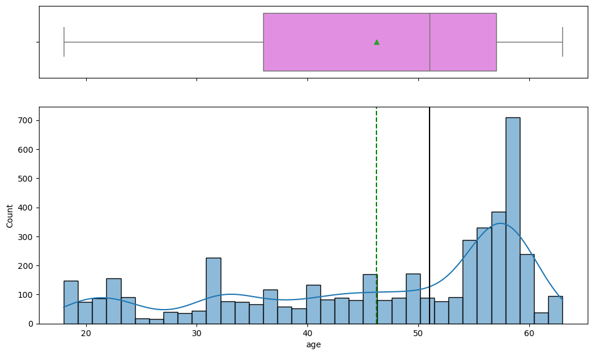

```python
histogram_boxplot(data, "age", kde = True, bins = 35)
```

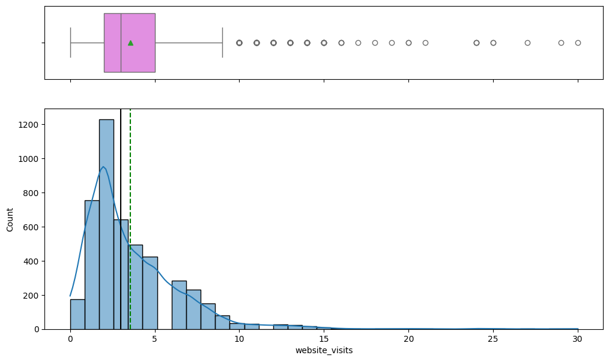

```python
histogram_boxplot(data, "website_visits", kde = True, bins = 35)
```

- The figure is rigth skewed with a majority of leads being visiting the website between 0 and 5 tiimes.

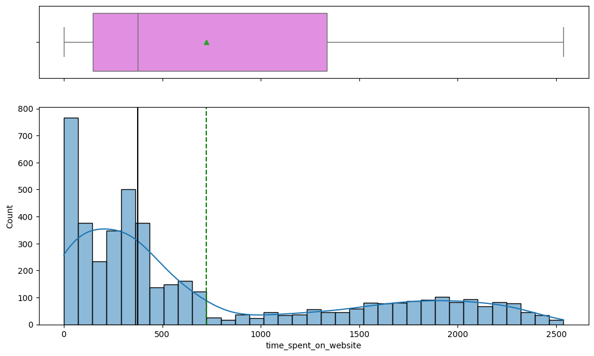

```python
histogram_boxplot(data, "time_spent_on_website", kde = True, bins = 35)
```

- We can notice that the distribution of the total time spent on website is bimodal with a first pick at 230 secondes and the second at 2000 seconds.

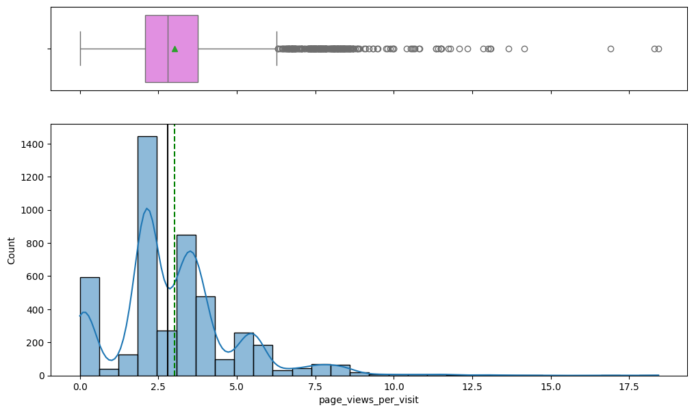

```python
histogram_boxplot(data, "page_views_per_visit", kde = True, bins = 30)
```

- The variable page_views_per_visit is multimodal with different picks and modes.

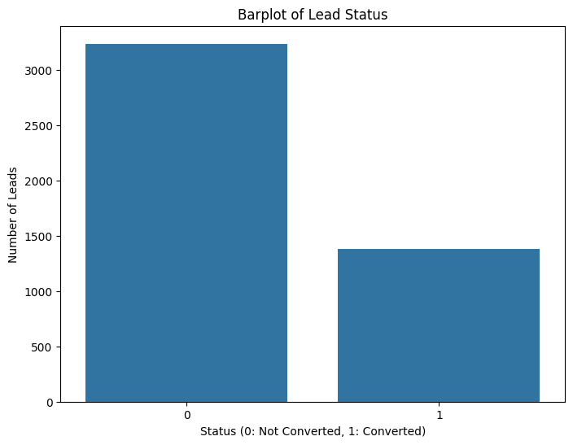

```python
# countplot for the target variable

plt.figure(figsize=(8, 6))
sns.countplot(x='status', data=data)
plt.title('Barplot of Lead Status')
plt.xlabel('Status (0: Not Converted, 1: Converted)')
plt.ylabel('Number of Leads')
plt.show()
```

- About 13OO leads have been converted over the total of 4612 leads.

## Bivariate analysis

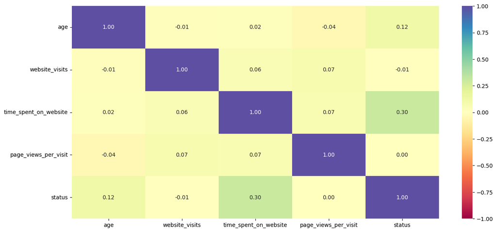

```python
# Exclude non-numeric columns
numeric_data = data.select_dtypes(include=np.number)

# Create heatmap
plt.figure(figsize=(15, 7))
sns.heatmap(numeric_data.corr(), annot=True, vmin=-1, vmax=1, fmt=".2f", cmap="Spectral")
plt.show()
```

Let's create a function that will be helpful in drawing our target variable vs the predictor one.

```python
# Function to plot stacked bar plots

def stacked_barplot(data, predictor, target):

    count = data[predictor].nunique()
    sorter = data[target].value_counts().index[-1]
    tab1 = pd.crosstab(data[predictor], data[target], margins = True).sort_values(
        by = sorter, ascending = False
    )
    print(tab1)
    print("-" * 120)
    tab = pd.crosstab(data[predictor], data[target], normalize = "index").sort_values(
        by = sorter, ascending = False
    )
    tab.plot(kind = "bar", stacked = True, figsize = (count + 1, 5))
    plt.legend(
        loc = "lower left",
        frameon = False,
    )
    plt.legend(loc = "upper left", bbox_to_anchor = (1, 1))
    plt.show()
```

```
status                 0     1   All
current_occupation
All                 3235  1377  4612
Professional        1687   929  2616
Unemployed          1058   383  1441
Student              490    65   555
------------------------------------------------------------------------------------------------------------------------
```

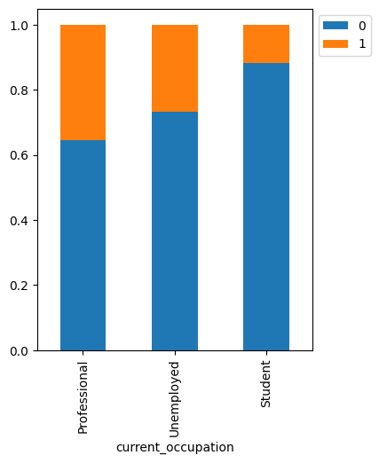

```python
stacked_barplot(data, "current_occupation", "status")
```

- Here the professional leads are more likely to be converted than the student or the unemployed ones.

```
status                0     1   All
first_interaction
All                3235  1377  4612
Website            1383  1159  2542
Mobile App         1852   218  2070
------------------------------------------------------------------------------------------------------------------------
```

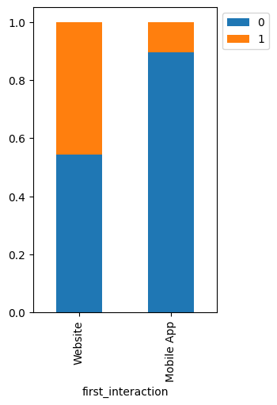

```python
stacked_barplot(data, "first_interaction", "status")
```

- The leads who use the website for their first interaction are more likely to be converted than those who uses mobile app.
- This is maybe due to the fact that the leads who are converted are in the first place professionals and then they have more chance to use the website in their interaction.

```
status                0     1   All
profile_completed
All                3235  1377  4612
High               1318   946  2264
Medium             1818   423  2241
Low                  99     8   107
------------------------------------------------------------------------------------------------------------------------
```

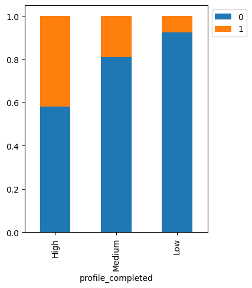

```python
stacked_barplot(data, "profile_completed", "status")
```

- The leads who have highly completed their profiles are more likely to be converted.

```
status               0     1   All
last_activity
All               3235  1377  4612
Email Activity    1587   691  2278
Website Activity   677   423  1100
Phone Activity     971   263  1234
------------------------------------------------------------------------------------------------------------------------
```

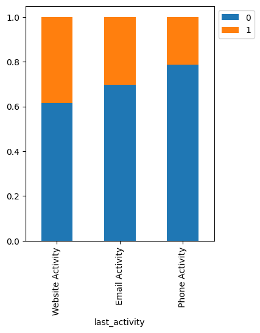

```python
stacked_barplot(data, "last_activity", "status")
```

```
status                0     1   All
print_media_type1
All                3235  1377  4612
No                 2897  1218  4115
Yes                 338   159   497
------------------------------------------------------------------------------------------------------------------------
```

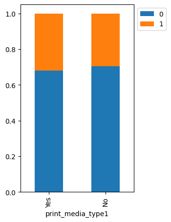

```python
stacked_barplot(data, "print_media_type1", "status")
```

```
status                0     1   All
print_media_type2
All                3235  1377  4612
No                 3077  1302  4379
Yes                 158    75   233
------------------------------------------------------------------------------------------------------------------------
```

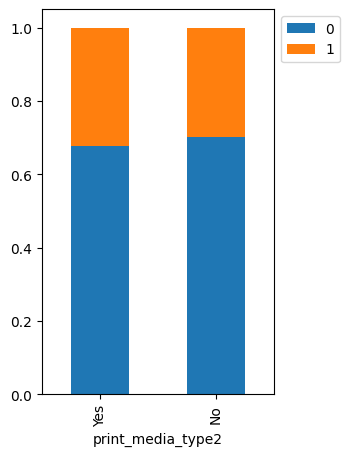

```python
stacked_barplot(data, "print_media_type2", "status")
```

```
status            0     1   All
digital_media
All            3235  1377  4612
No             2876  1209  4085
Yes             359   168   527
------------------------------------------------------------------------------------------------------------------------
```

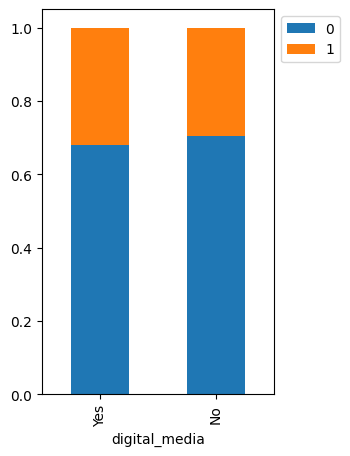

```python
stacked_barplot(data, "digital_media", "status")
```

- From the 3 plots above we can say that the media in which the lead have seen the add for the compagny doesn't matter in the way he will be converted or not.

```
status       0     1   All
referral
All       3235  1377  4612
No        3205  1314  4519
Yes         30    63    93
------------------------------------------------------------------------------------------------------------------------
```

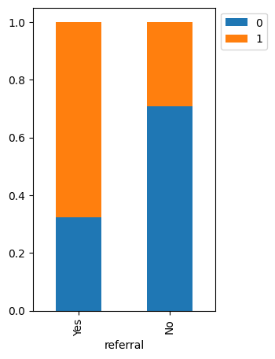

```python
stacked_barplot(data, "referral", "status")
```

-The convertion ratio of the leads with referral is 67% when it's only 29% for those without.

```
status                   0     1   All
educational_channels
All                   3235  1377  4612
No                    2727  1180  3907
Yes                    508   197   705
------------------------------------------------------------------------------------------------------------------------
```

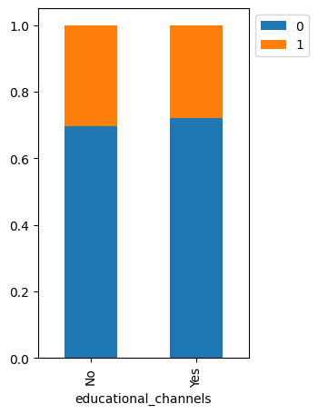

```python
stacked_barplot(data, "educational_channels", "status")
```

- No evident change in the two behaviors.

## Data pre-processing

- Before building our models, we will have to encode our categorical variables.
- Also we will have to sparate the independent variables and dependent Variables.
- We will split the data into train set and test set.

```python
# Creating dummy variables for the categorical columns
# drop_first=False to avoid supressing important variables
data = pd.get_dummies(
    data,
    columns = data.select_dtypes(include = ["object", "category"]).columns.tolist(),
    drop_first=False
)
```

```python
data.head()
```

|  | age | website_visits | time_spent_on_website | page_views_per_visit | status | current_occupation_Professional | current_occupation_Student | current_occupation_Unemployed | first_interaction_Mobile App | first_interaction_Website | profile_completed_High | profile_completed_Low | profile_completed_Medium | last_activity_Email Activity | last_activity_Phone Activity | last_activity_Website Activity | print_media_type1_No | print_media_type1_Yes | print_media_type2_No | print_media_type2_Yes | digital_media_No | digital_media_Yes | educational_channels_No | educational_channels_Yes | referral_No | referral_Yes |
| --- | --- | --- | --- | --- | --- | --- | --- | --- | --- | --- | --- | --- | --- | --- | --- | --- | --- | --- | --- | --- | --- | --- | --- | --- | --- | --- |
| 0 | 57 | 7 | 1639 | 1.861 | 1 | False | False | True | False | True | True | False | False | False | False | True | False | True | True | False | False | True | True | False | True | False |
| 1 | 56 | 2 | 83 | 0.320 | 0 | True | False | False | True | False | False | False | True | False | False | True | True | False | True | False | True | False | False | True | True | False |
| 2 | 52 | 3 | 330 | 0.074 | 0 | True | False | False | False | True | False | False | True | False | False | True | True | False | True | False | False | True | True | False | True | False |
| 3 | 53 | 4 | 464 | 2.057 | 1 | False | False | True | False | True | True | False | False | False | False | True | True | False | True | False | True | False | True | False | True | False |
| 4 | 23 | 4 | 600 | 16.914 | 0 | False | True | False | False | True | True | False | False | True | False | False | True | False | True | False | True | False | True | False | True | False |

```python
# Separating independent variables and the target variable
x = data.drop('status',axis=1)

y = data['status']
```

```python
# Splitting the dataset into train and test datasets with weight 0.2
# random_state to 1 to have the ability to reconduct the experience
x_train, x_test, y_train, y_test = train_test_split(x, y, test_size = 0.2, shuffle = True, random_state = 1)
```

```python
# Checking the shape of the train and test data
print("Shape of Training set : ", x_train.shape)
print("Shape of test set : ", x_test.shape)
```

```
Shape of Training set :  (3689, 25)
Shape of test set :  (923, 25)
```

**Model evaluation criterion**

**The model can make two types of wrong predictions:**

1. Predicting a lead will be converted while he will not.(error type 1)
2. Predicting a lead will not be converted when he will.(error type 2).
- Now one can easily identify the first error as the most damageable for the compagny because if the model predicts that a lead is convertable then that lead will concentrate all the energy of the comagny to make him really converted.
- so here we have to reduce the quantity of false positives (maximizing the precision function) and it should be our priority in building the metrics.

Also, let's create a function to calculate and print the classification report and confusion matrix so that we don't have to rewrite the same code repeatedly for each model.

```python
# Creating metric function
def metrics_score(actual, predicted):
    print(classification_report(actual, predicted))

    cm = confusion_matrix(actual, predicted)
    plt.figure(figsize=(8,5))

    sns.heatmap(cm, annot=True,  fmt='.2f', xticklabels=['Not converted', 'Converted'], yticklabels=['Not converted', 'converted'])
    plt.ylabel('Actual')
    plt.xlabel('Predicted')
    plt.show()
```

## Building a Decision Tree model

```
              precision    recall  f1-score   support

           0       1.00      1.00      1.00      2600
           1       1.00      1.00      1.00      1089

    accuracy                           1.00      3689
   macro avg       1.00      1.00      1.00      3689
weighted avg       1.00      1.00      1.00      3689
```

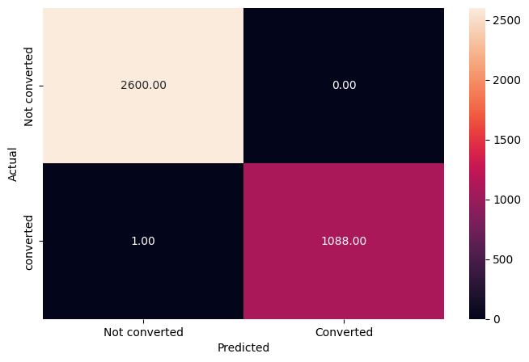

```python
# Decision Tree Regressor
dt_cat=DecisionTreeClassifier(random_state=1)

# Fitting the model
dt_cat.fit(x_train, y_train)

# Checking performance on the training dataset
y_train_pred_dt = dt_cat.predict(x_train)

# Model Performance on the test data
metrics_score(y_train, y_train_pred_dt)
```

- The Decision tree is giving a 100% score for all metrics on the training dataset.Let's check if this performence will stand in the test dataset.

```
              precision    recall  f1-score   support

           0       0.86      0.89      0.87       635
           1       0.73      0.69      0.71       288

    accuracy                           0.82       923
   macro avg       0.80      0.79      0.79       923
weighted avg       0.82      0.82      0.82       923
```

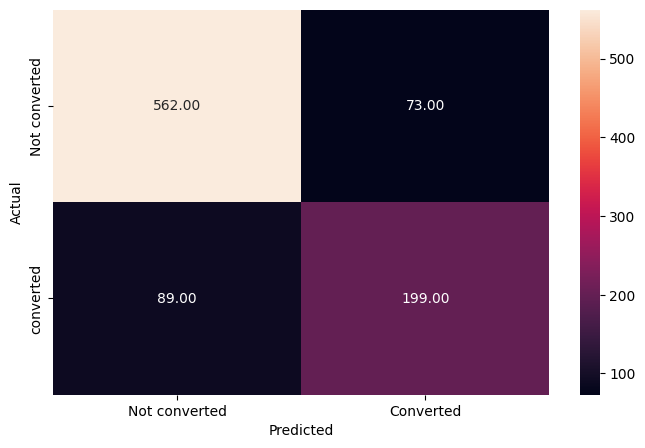

```python
# Checking performance on the test dataset
y_test_pred_dt = dt_cat.predict(x_test)

metrics_score(y_test, y_test_pred_dt)
```

- As we can see the precision and the recall has fallen down to acceptable values but still inferior to what we had in the training dataset.
- Now Let's plot the feature importance and check the most important features.

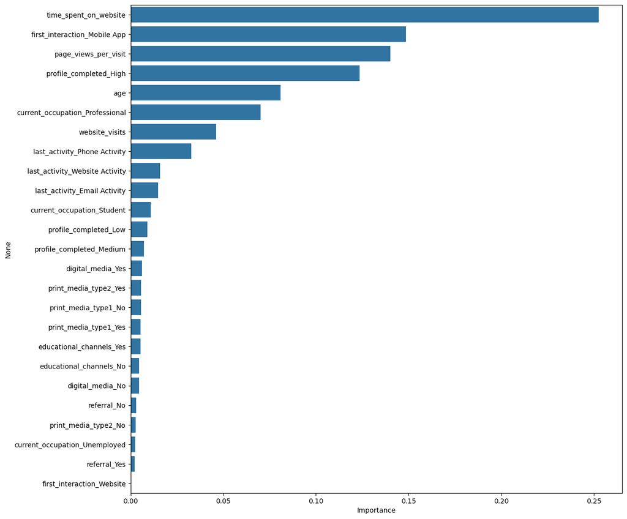

```python
# Plot the feature importance

importances = dt_cat.feature_importances_
columns = x_train.columns
importance_df = pd.DataFrame(importances, index = columns, columns = ['Importance']).sort_values(by = 'Importance', ascending = False)
plt.figure(figsize = (13, 13))
sns.barplot(data = importance_df, x = importance_df.Importance, y = importance_df.index)
```

# **Observations:**

- According to our model,time_spent_on_website, followed by first_interaction_Mobile_App, age_views_per_visit and profile_completed_High are the most important features in the decision tree. All these features denote an interest showed by the lead toward the offer of the compagny.
- Now let's check for optimal values of the hyperparameters for our decision tree.

```
Best Hyperparameters: {'criterion': 'entropy', 'max_depth': 10}
              precision    recall  f1-score   support

           0       0.88      0.90      0.89       635
           1       0.77      0.72      0.74       288

    accuracy                           0.85       923
   macro avg       0.82      0.81      0.82       923
weighted avg       0.84      0.85      0.84       923
```

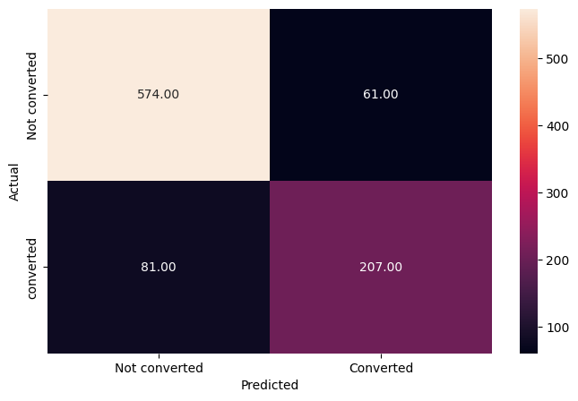

```python
# Create a DecisionTreeClassifier instance
dt_tuned = DecisionTreeClassifier(random_state=1)

# Define the parameter grid to search over
dt_parameters = {
    "max_depth": [None, 10, 20, 30],  # Example depth values
    "criterion": ["gini", "entropy"] # Example criteria
}

# Create the GridSearchCV object
dt_grid_obj = GridSearchCV(dt_tuned, dt_parameters, cv=5, scoring='precision') # Example scoring

# Fit the grid search to your training data
dt_grid_obj.fit(x_train, y_train)

# Get the best estimator (model with the best hyperparameters)
dt_tuned_classifier = dt_grid_obj.best_estimator_

# Print the best hyperparameters
print("Best Hyperparameters:", dt_grid_obj.best_params_)

# Evaluate the tuned model (example using test data)
y_pred = dt_tuned_classifier.predict(x_test)
metrics_score(y_test, y_pred)
```

- We notice that 10 is the best depth for our decision tree model. It imroves the precision for the cenverted leads by 4 points passing from 0.73 to 0.77.
- So to fix the probleme of overfitting in our model we have to prune our tree to the depth of 10.

## Building a Random Forest model

```python
# Fitting the Random Forest classifier on the training data
rf_estimator = RandomForestClassifier( random_state = 1)

rf_estimator.fit(x_train, y_train)
```

```
RandomForestClassifier(random_state=1)
```

```
              precision    recall  f1-score   support

           0       1.00      1.00      1.00      2600
           1       1.00      1.00      1.00      1089

    accuracy                           1.00      3689
   macro avg       1.00      1.00      1.00      3689
weighted avg       1.00      1.00      1.00      3689
```

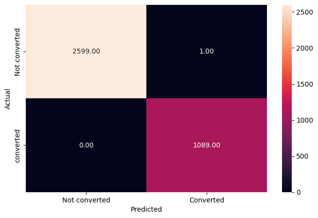

```python
# Checking performance on the training data
y_pred_train_rf = rf_estimator.predict(x_train)

metrics_score(y_train, y_pred_train_rf)
```

- For all the metrics in the training dataset, the Random Forest gives a 100% score.
- Let's check now for the performence in the test dataset.

```
              precision    recall  f1-score   support

           0       0.87      0.93      0.90       635
           1       0.81      0.70      0.75       288

    accuracy                           0.85       923
   macro avg       0.84      0.81      0.82       923
weighted avg       0.85      0.85      0.85       923
```

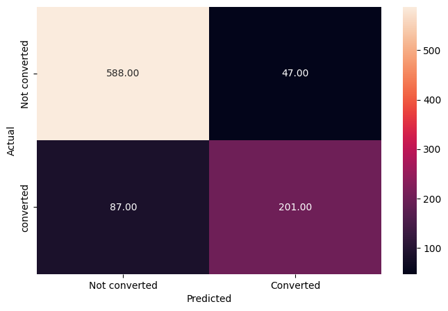

```python
# Checking performance on the testing data
y_pred_test_rf = rf_estimator.predict(x_test)

metrics_score(y_test, y_pred_test_rf)
```

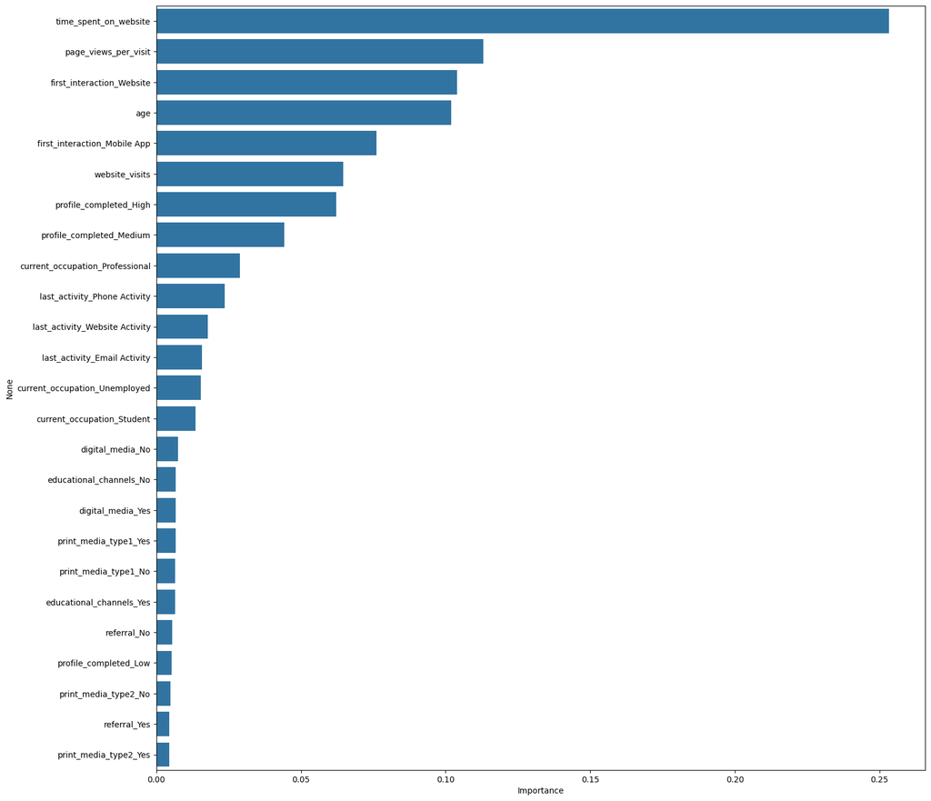

```python
importances = rf_estimator.feature_importances_
columns = x_train.columns
importance_df = pd.DataFrame(importances, index = columns, columns = ['Importance']).sort_values(by = 'Importance', ascending = False)
plt.figure(figsize = (17, 17))
sns.barplot(data = importance_df, x = importance_df.Importance, y = importance_df.index)
```

```
Best Hyperparameters: {'criterion': 'gini', 'max_depth': 10}
              precision    recall  f1-score   support

           0       0.88      0.94      0.90       635
           1       0.83      0.71      0.77       288

    accuracy                           0.86       923
   macro avg       0.85      0.82      0.84       923
weighted avg       0.86      0.86      0.86       923
```

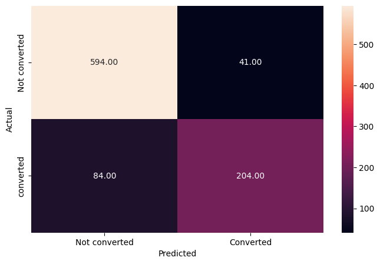

```python
# Create a Random Forest Classifier instance
rf_tuned = RandomForestClassifier(random_state=1)

# Define the parameter grid to search over
rf_parameters = {
    "max_depth": [None, 10, 20, 30],  # Example depth values
    "criterion": ["gini", "entropy"] # Example criteria
}

# Create the GridSearchCV object
rf_grid_obj = GridSearchCV(rf_tuned, rf_parameters, cv=5, scoring='precision') # Example scoring

# Fit the grid search to your training data
rf_grid_obj.fit(x_train, y_train)

# Get the best estimator (model with the best hyperparameters)
rf_tuned_classifier = rf_grid_obj.best_estimator_

# Print the best hyperparameters
print("Best Hyperparameters:", rf_grid_obj.best_params_)

# Evaluate the tuned model (example using test data)
y_pred = rf_tuned_classifier.predict(x_test)
metrics_score(y_test, y_pred)
```

- We can see that pruning our random forest to depth 10 improves the precision in both classes 0 and 1 passing from 0.87 and 0.81 to 0.88 and 0.83 respectively.
- From both models decision tree and random forest we can easily conclude to the net imrovements of the precision and all metrivs for the second one.

## Actionable Insights and Recommendations

- As seen before the professionals are the category the most convertible so the compagny should target this category by advertisement and also by conceiving academic programmes more adapted to them. -For the two other categories, one can easily figure out the reason behind the low conversion : money. So the compagny should invente new offers less expensive to adapt its offer to these 2 categories. -We also saw that there is no difference in the convertion ratio between the different ways of advertising. Hence, the compagny should not privilege one of theme and try to devirsify its ways of advertising.
- The leads who use the website for their first interaction are more likely to be converted than those who uses mobile app : this is maybe due to the level of trust high in the website but low on mobile app. So the compagny shouuld improve the design of the app to look more professional.
- The compagny should also target the leads who complete their profile with a high level since they show more interest and also their convertion ratio is high.
- The compagny should initiate (if not the case) a policy that encourages past students to be references for the leads. -Finally the compagny can use the model developed above to predict the convertible leads.